# Homework 7 Solutions

##### R square

We can also make a selection based on the adjusted $R^2_a$ as follows:

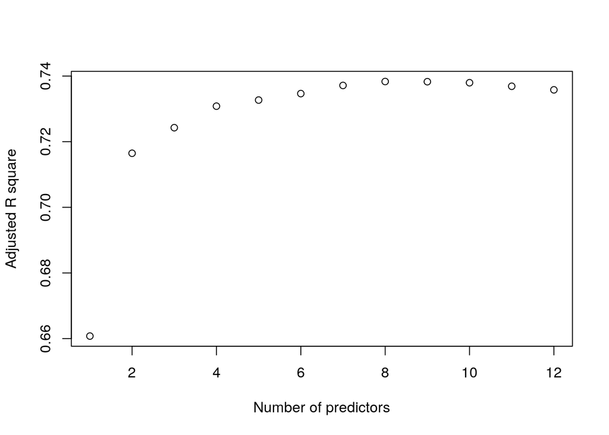

```r
plot(c(1:12),sum_fat$adjr2, xlab = "Number of predictors", ylab="Adjusted R square")
```

```r
rsquare <- sum_fat$adjr2
which(rsquare==max(rsquare))
```

```
## [1] 8
```

```r
lm_r_square <- lm(brozek ~ age + weight + neck + abdom + thigh + forearm + wrist, data=fat)
summary(lm_r_square)
```

```
##
## Call:
## lm(formula = brozek ~ age + weight + neck + abdom + thigh + forearm +
##     wrist, data = fat)
##
## Residuals:
##      Min       1Q   Median       3Q      Max
## -10.0193  -2.8016  -0.1234   2.9387   9.0019
##
## Coefficients:
##              Estimate Std. Error t value Pr(>|t|)
## (Intercept) -30.17420    8.34200  -3.617 0.000362 ***
## age           0.06149    0.02852   2.156 0.032047 *
## weight       -0.11236    0.03151  -3.565 0.000437 ***
## neck         -0.37203    0.20434  -1.821 0.069876 .
## abdom         0.85152    0.06437  13.229  < 2e-16 ***
## thigh         0.20973    0.10745   1.952 0.052099 .
## forearm       0.51824    0.17115   3.028 0.002726 **
## wrist        -1.40081    0.47274  -2.963 0.003346 **
## ---
## Signif. codes:  0 '***' 0.001 '**' 0.01 '*' 0.05 '.' 0.1 ' ' 1
##
## Residual standard error: 3.974 on 244 degrees of freedom
## Multiple R-squared:  0.7445, Adjusted R-squared:  0.7371
## F-statistic: 101.6 on 7 and 244 DF,  p-value: < 2.2e-16
```

##### Mallow’s Cp

Finally, we study the fit using Mallow’s Cp statistic. Here, numbers around the line $C_p =$ “number of parameters” are favored, but we always favor smaller models and ones with $C_p$ value under the line. Here the best choice is with 8 explanatory variables (9 parameters).

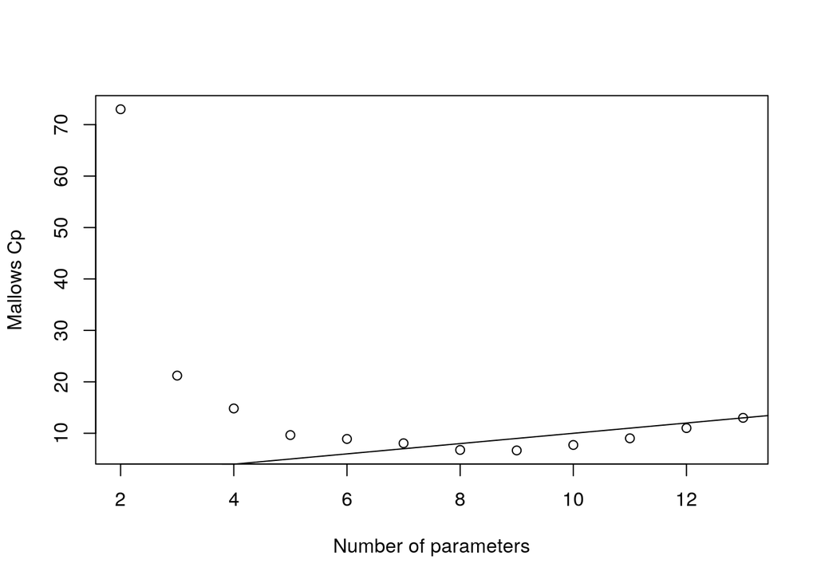

```r
plot(c(2:13),sum_fat$cp, xlab = "Number of parameters", ylab="Mallows Cp")
abline(0,1)
```

```r
CP <- sum_fat$cp
which(CP == min(CP))
```

```
## [1] 8
```

##### Discussion

```r
anova(lm_BIC, lm_r_square)
```

```
## Analysis of Variance Table
##
## Model 1: brozek ~ weight + neck + abdom + forearm
## Model 2: brozek ~ age + weight + neck + abdom + thigh + forearm + wrist
##   Res.Df    RSS Df Sum of Sq      F   Pr(>F)
## 1    247 4064.0
## 2    244 3853.2  3    210.77 4.4489 0.004592 **
## ---
## Signif. codes:  0 '***' 0.001 '**' 0.01 '*' 0.05 '.' 0.1 ' ' 1
```

```r
anova(lm_backwards_selection, lm_r_square)
```

```
## Analysis of Variance Table
##
## Model 1: brozek ~ weight + abdom + forearm + wrist
## Model 2: brozek ~ age + weight + neck + abdom + thigh + forearm + wrist
##   Res.Df    RSS Df Sum of Sq      F  Pr(>F)
## 1    247 3994.3
## 2    244 3853.2  3     141.1 2.9783 0.03217 *
## ---
## Signif. codes:  0 '***' 0.001 '**' 0.01 '*' 0.05 '.' 0.1 ' ' 1
```

In both cases, we reject the null at $5\%$ significance. The model we favor should be decided in large part by the diagnostics and which model is performing better with respect to our assumptions If more than one model is comparable, we might favor the 8 predictor model for prediction purposes, but favor the 4 predictor model(s) for explanation purposes due to the simplicity (and because these are embedded sub-models).